# Ryanair Task - Regression model

- Problem definition
- Solving methodology
  - 1. Setup
  - 2. Load CSV data and perform initial exploration
  - 3. Process data frame features
  - 4. Exploratory data analysis
  - 5. Prepare features for modeling
  - 6. Train and evaluate models
    - 6.1. Regression models description
    - 6.2. Model performance parameters description
  - 7. Generate predictions for new data
  - 8. Visualize predictions
  - 9. Visualize model performance
- Results

## Problem definition

This project aims to develop a robust regression model for predicting aircraft Take-Off Weight (TOW), a critical parameter in aviation operations that directly impacts fuel consumption, flight planning, and operational efficiency.

**Analysis datasets**

- Training Dataset (*training.csv*): Historical flight data from Ryanair operations spanning October 1-15, 2016, containing comprehensive flight parameters and corresponding Take-Off Weight measurements for model development and training.
- Validation Dataset (*validation.csv*): A separate dataset with identical feature structure but without Take-Off Weight values, serving as the prediction target for model validation and performance assessment.

**Performance criteria**

Model performance is evaluated using **Root Mean Square Error (RMSE)**, which provides:

- Interpretable error metrics in the same units as the target variable
- Appropriate penalty for larger prediction errors
- Industry-standard benchmark for regression model assessment

## Solving methodology

### 1. Setup

*Import all necessary libraries.*

```python
import pandas as pd
import numpy as np
import matplotlib.pyplot as plt
import seaborn as sns
from sklearn.model_selection import train_test_split
from sklearn.linear_model import LinearRegression, Ridge, Lasso
from sklearn.ensemble import RandomForestRegressor, GradientBoostingRegressor
from sklearn.metrics import mean_absolute_error, mean_squared_error, r2_score, mean_absolute_percentage_error
from sklearn.preprocessing import StandardScaler, LabelEncoder
import warnings
warnings.filterwarnings('ignore')
```

| Import | Usage |
| --- | --- |
| `pandas as pd` | Data manipulation and analysis; used for working with DataFrames. |
| `numpy as np` | Numerical computing; provides support for arrays and mathematical functions. |
| `matplotlib.pyplot as plt` | Visualization library for creating static plots (e.g., bar, line, scatter). |
| `seaborn as sns` | Statistical data visualization built on top of matplotlib; used for enhanced plots. |
| `train_test_split` | Splits data into training and testing sets. |
| `LinearRegression` | Linear regression model for predictive modeling. |
| `Ridge` | Regularized linear regression that reduces overfitting (L2 penalty). |
| `Lasso` | Linear regression with feature selection (L1 penalty). |
| `RandomForestRegressor` | Ensemble model using multiple decision trees for regression tasks. |
| `GradientBoostingRegressor` | Boosting algorithm combining weak learners to improve performance. |
| `mean_absolute_error` | Metric to evaluate average absolute errors between predicted and actual values. |
| `mean_squared_error` | Metric to evaluate the average squared errors (sensitive to outliers). |
| `r2_score` | Metric to evaluate the proportion of variance explained by the model. |
| `mean_absolute_percentage_error` | Error metric showing average absolute error as a percentage of true value. |
| `StandardScaler` | Scales features to have mean = 0 and standard deviation = 1. |
| `LabelEncoder` | Encodes categorical labels as integers. |
| `warnings.filterwarnings('ignore')` | Suppresses warnings during code execution for cleaner output. |

*Configure plot style.*

```python
plt.style.use('seaborn-v0_8')
sns.set_palette("husl")
```

*Initialize models.*

```python
models = {}
scaler = StandardScaler()
```

### 2. Load CSV data and perform initial exploration

*Save CSV file as DataFrame.*

```python
df = pd.read_csv('training.csv', sep='\t', na_values=['(null)'])

print(f"Dataset shape: {df.shape}")
print(f"Date range: {df['DepartureDate'].min()} to {df['DepartureDate'].max()}")
```

```
Dataset shape: (29731, 14)
Date range: 01/10/2016 to 15/10/2016
```

After running this code, it is known that the dataset contains **29,731 rows** and **14 columns**. It covers flight records from **October 1st, 2016** to **October 15th, 2016**.

Additionally, values labeled as *"(null)"* in the file are automatically treated as missing *(NaN)* in the DataFrame.

**Basic dataset info:**

```python
print(df.info())
```

```
<class 'pandas.core.frame.DataFrame'>
RangeIndex: 29731 entries, 0 to 29730
Data columns (total 14 columns):
 #   Column            Non-Null Count  Dtype
---  ------            --------------  -----
 0   DepartureDate     29731 non-null  object
 1   DepartureYear     29731 non-null  int64
 2   DepartureMonth    29731 non-null  int64
 3   DepartureDay      29731 non-null  int64
 4   FlightNumber      29731 non-null  int64
 5   DepartureAirport  29731 non-null  object
 6   ArrivalAirport    29731 non-null  object
 7   Route             29731 non-null  object
 8   ActualFlightTime  29731 non-null  int64
 9   ActualTotalFuel   29731 non-null  int64
 10  ActualTOW         29298 non-null  float64
 11  FLownPassengers   29636 non-null  float64
 12  BagsCount         27447 non-null  float64
 13  FlightBagsWeight  27253 non-null  float64
dtypes: float64(4), int64(6), object(4)
memory usage: 3.2+ MB
None
```

**NaN values count in dataset:**

```python
print(df.isnull().sum())
```

```
DepartureDate          0
DepartureYear          0
DepartureMonth         0
DepartureDay           0
FlightNumber           0
DepartureAirport       0
ArrivalAirport         0
Route                  0
ActualFlightTime       0
ActualTotalFuel        0
ActualTOW            433
FLownPassengers       95
BagsCount           2284
FlightBagsWeight    2478
dtype: int64
```

**Basic dataset statistics:**

```python
print(df.describe())
```

```
       DepartureYear  DepartureMonth  DepartureDay  FlightNumber  \
count        29731.0         29731.0  29731.000000  29731.000000
mean          2016.0            10.0      7.987723   4814.133934
std              0.0             0.0      4.313351   3062.612334
min           2016.0            10.0      1.000000      1.000000
25%           2016.0            10.0      4.000000   2087.000000
50%           2016.0            10.0      8.000000   4765.000000
75%           2016.0            10.0     12.000000   7496.000000
max           2016.0            10.0     15.000000   9998.000000

       ActualFlightTime  ActualTotalFuel     ActualTOW  FLownPassengers  \
count      29731.000000     29731.000000  29298.000000     29636.000000
mean         110.069221      4782.483536  65031.246638       167.268626
std           52.457470      2069.865460   3339.385728        20.177527
min            2.000000       600.000000  42991.000000         4.000000
25%           73.000000      3210.000000  63127.000000       163.000000
50%          105.000000      4530.000000  65122.000000       173.000000
75%          140.000000      6010.000000  67154.000000       179.000000
max         1504.000000     17890.000000  74283.000000       189.000000

          BagsCount  FlightBagsWeight
count  27447.000000      27253.000000
mean      45.417022        573.618464
std       32.797217        376.524581
min        1.000000          3.000000
25%       23.000000        300.000000
50%       39.000000        490.000000
75%       62.000000        780.000000
max     1180.000000      10530.000000
```

### 3. Process data frame features

This step performs preprocessing and feature engineering to prepare the dataset for modeling:

- **Data Type Conversion**: Convert relevant columns (especially dates and numerics) to appropriate types for analysis.
- **Missing Value Handle**:
  - Baggage counts - estimates are computed using an average of 0.7 bags per passenger.
  - Baggage weights - estimates assume 15 kg per bag.
- **New Feature Engineer**: Calculate several derived metrics:
  - **FuelPerPassenger** – average fuel consumption (kg) per passenger.
  - **BagLoadFactor** – average number of bags per passenger.
  - **Month** – extracted from the flight's departure date.
  - **DayOfWeek** – numeric representation of the weekday (0 = Monday, 6 = Sunday).
  - **IsWeekend** – binary indicator for weekend flights (Saturday or Sunday).
  - **EstimatedDistance** – estimated distance of the route in kilometers; based on known routes or average distance if unknown.

This preprocessing ensures consistency, fills data gaps intelligently, and enriches the dataset with meaningful features for model training and evaluation.

```python
def _process_dataframe_features(df, is_training=True):
        """Helper method to process features for both training and prediction data"""

        if 'DepartureDate' in df.columns:
            df['DepartureDate'] = pd.to_datetime(df['DepartureDate'], format='%d/%m/%Y')

        # Convert numeric columns and handle missing values
        numeric_columns = ['ActualTotalFuel', 'FLownPassengers', 'FlightBagsWeight', 'BagsCount', 'ActualFlightTime']
        if is_training:
            numeric_columns.append('ActualTOW')

        for col in numeric_columns:
            if col in df.columns:
                df[col] = pd.to_numeric(df[col], errors='coerce')

        # Handle missing bag data
        missing_bags = df['BagsCount'].isnull()
        missing_bag_weight = df['FlightBagsWeight'].isnull()

        # Estimate missing bag counts (0.7 bags per passenger average)
        df.loc[missing_bags, 'BagsCount'] = (df.loc[missing_bags, 'FLownPassengers'] * 0.7).round()

        # Estimate missing bag weights (15kg per bag average)
        df.loc[missing_bag_weight, 'FlightBagsWeight'] = df.loc[missing_bag_weight, 'BagsCount'] * 15

        # Fuel efficiency metrics
        df['FuelPerPassenger'] = df['ActualTotalFuel'] / df['FLownPassengers']

        # Load factors
        df['BagLoadFactor'] = df['BagsCount'] / df['FLownPassengers']

        # Temporal features
        if 'DepartureDate' in df.columns:
            df['Month'] = df['DepartureDate'].dt.month
            df['DayOfWeek'] = df['DepartureDate'].dt.dayofweek
            df['IsWeekend'] = (df['DayOfWeek'] >= 5).astype(int)

        route_distances = {
            'KUN-RHO': 2084,  # Kaunas to Rhodes
            'STN-KRK': 1378,  # London Stansted to Krakow
            'KRK-STN': 1378,  # Krakow to London Stansted
            'STN-LCJ': 1313,  # London Stansted to Lodz
            'LBA-TSF': 1346,  # Leeds Bradford to Treviso
            'BCN-CGN': 1132,  # Barcelona to Cologne
            'CGN-BCN': 1132,  # Cologne to Barcelona
            'AGP-BLL': 2354,  # Malaga to Billund
            'NYO-AGP': 2987,  # Stockholm Skavsta to Malaga
            'AGP-SXF': 2112,  # Malaga to Berlin Schönefeld
            'PDL-LIS': 1452,  # Ponta Delgada to Lisbon
            'STN-CIA': 1434,  # London Stansted to Rome Ciampino
            'BRU-PMI': 1329,  # Brussels to Palma de Mallorca
            'BRU-BCN': 1065,  # Brussels to Barcelona
            'MRS-BES': 624,   # Marseille to Brest
            'BES-MRS': 624,   # Brest to Marseille
            'MRS-STN': 1004,  # Marseille to London Stansted
            'STN-MRS': 1004,  # London Stansted to Marseille
            'STN-REU': 1213,  # London Stansted to Reus
            'REU-STN': 1213,  # Reus to London Stansted
            'STN-DUB': 463,   # London Stansted to Dublin
            'DUB-STN': 463,   # Dublin to London Stansted
            'STN-NYO': 1420,  # London Stansted to Stockholm Skavsta
            'GDN-NYO': 789    # Gdansk to Stockholm Skavsta
        }
        mean_distance = sum(route_distances.values()) / len(route_distances)
        df['EstimatedDistance'] = df['Route'].map(route_distances).fillna(mean_distance)

        return df

df = _process_dataframe_features(df)
```

### 4. Exploratory data analysis

**Distribution of Actual TOW**

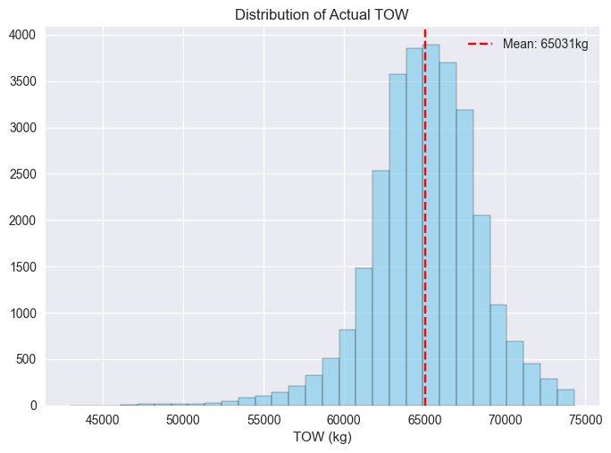

```python
plt.hist(df['ActualTOW'], bins=30, alpha=0.7, color='skyblue', edgecolor='black')
plt.axvline(df['ActualTOW'].mean(), color='red', linestyle='--', label=f'Mean: {df["ActualTOW"].mean():.0f}kg')
plt.title('Distribution of Actual TOW')
plt.xlabel('TOW (kg)')
plt.legend()
```

*Distribution of Actual TOW* histogram shows the frequency distribution of aircraft take-off weights. The data follows an approximately normal distribution with a mean of **65,031 kg**, indicated by a red dashed vertical line.

**TOW vs Number of Passengers**

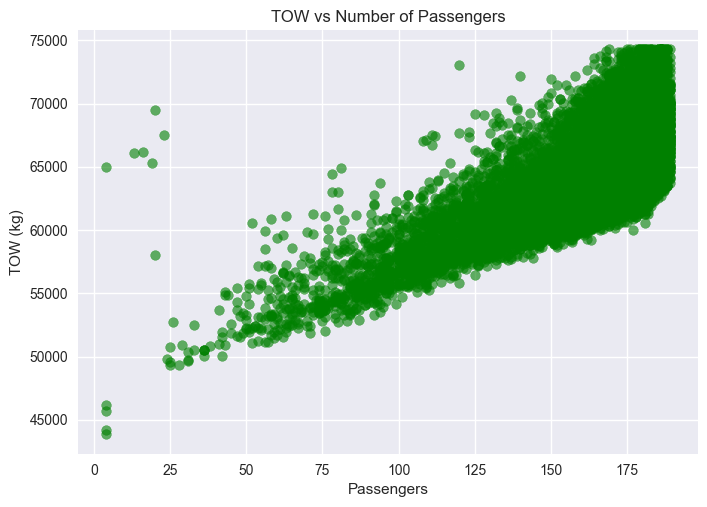

```python
plt.scatter(df['FLownPassengers'], df['ActualTOW'], alpha=0.6, color='green')
plt.title('TOW vs Number of Passengers')
plt.xlabel('Passengers')
plt.ylabel('TOW (kg)')
```

*TOW vs Number of Passengers* plot shows the relationship between passenger count (*x-axis*) and take-off weight (*y-axis*). The data displays a strong positive linear correlation, with TOW increasing consistently from around **45,000 kg** with minimal passengers to **75,000 kg** at maximum capacity **(~180 passengers)**.

The tight clustering of data points along the trend line indicates a predictable relationship between passenger load and aircraft weight, with some scatter likely due to varying cargo loads and fuel requirements.

**TOW vs Total Fuel**

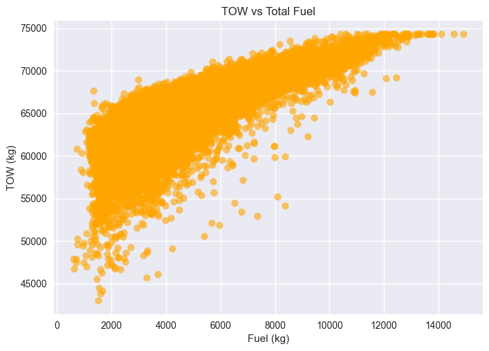

```python
plt.scatter(df['ActualTotalFuel'], df['ActualTOW'], alpha=0.6, color='orange')
plt.title('TOW vs Total Fuel')
plt.xlabel('Fuel (kg)')
plt.ylabel('TOW (kg)')
```

*TOW vs Total Fuel* plot displays the relationship between aircraft take-off weight (*y-axis*) and total fuel load (*x-axis*). The plot reveals a strong positive correlation, with data points forming a dense upward trend from approximately **45,000 kg** TOW with minimal fuel to **75,000 kg** TOW with maximum fuel loads around **14,000 kg**.

The relationship appears linear with some scatter, indicating fuel capacity constraints at different weight configurations.

**Flight Time vs TOW**

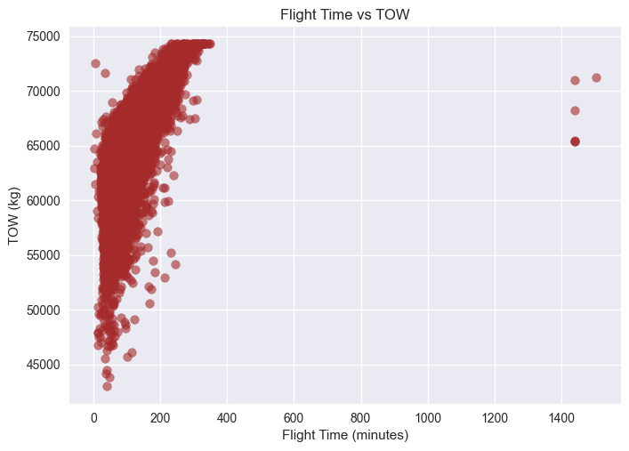

```python
plt.scatter(df['ActualFlightTime'], df['ActualTOW'], alpha=0.6, color='brown')
plt.title('Flight Time vs TOW')
plt.xlabel('Flight Time (minutes)')
plt.ylabel('TOW (kg)')
```

*Flight Time vs TOW* plot shows flight duration (*x-axis*) versus take-off weight (*y-axis*). Most data points cluster in the **0-400** minute range across all weight categories, with a dense concentration of flights lasting under **200 minutes**. Some outlier flights extend beyond **1,000 minutes**, likely representing long-haul operations.

**Fuel per Passenger vs TOW**

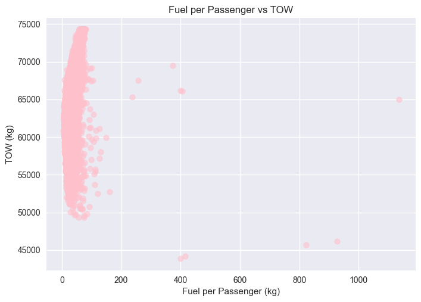

```python
plt.scatter(df['FuelPerPassenger'], df['ActualTOW'], alpha=0.6, color='pink')
plt.title('Fuel per Passenger vs TOW')
plt.xlabel('Fuel per Passenger (kg)')
plt.ylabel('TOW (kg)')
```

*Fuel per Passenger vs TOW* plot examines the relationship between fuel consumption per passenger (*x-axis*) and take-off weight (*y-axis*). The majority of data points concentrate in the **0-200 kg** fuel per passenger range across various TOW levels.

Some outliers show extremely high fuel per passenger ratios **(up to 1,000 kg)**, possibly indicating cargo flights or flights with very low passenger loads.

**Average TOW by Day Of Week**

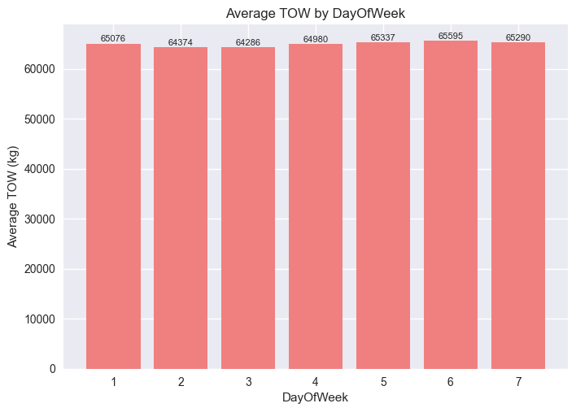

```python
day_tow = df.groupby('DayOfWeek')['ActualTOW'].mean()
plt.bar((day_tow.index) + 1, day_tow.values, color='lightcoral')
plt.title('Average TOW by DayOfWeek')
plt.xlabel('DayOfWeek')
plt.ylabel('Average TOW (kg)')

for i, (day, value) in enumerate(day_tow.items()):
    plt.text(i + 1, value + 50, f'{value:.0f}', ha='center', va='bottom', fontsize=8)
```

The variation is minimal, suggesting operational consistency throughout the week.

**Average TOW by Route (Top 10)**

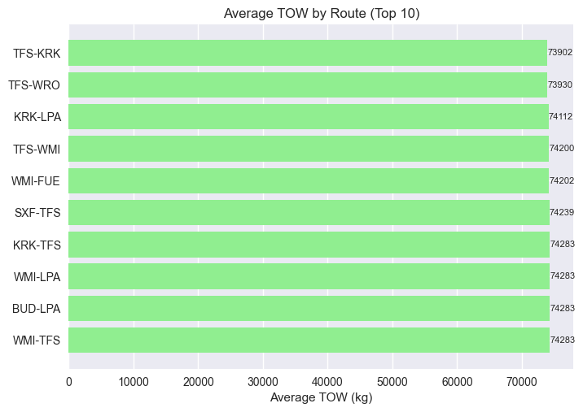

```python
route_tow = df.groupby('Route')['ActualTOW'].mean().sort_values(ascending=False).head(10)
plt.barh(range(len(route_tow)), route_tow.values, color='lightgreen')
plt.yticks(range(len(route_tow)))
ax = plt.gca()
ax.set_yticklabels(route_tow.index)
plt.title('Average TOW by Route (Top 10)')
plt.xlabel('Average TOW (kg)')

for i, value in enumerate(route_tow.values):
    plt.text(value + 50, i, f'{value:.0f}', va='center', fontsize=8)
```

*Average TOW by Route (Top 10)* bar chart shows the top 10 routes ranked by average take-off weight. Values cluster tightly between **73,900-74,300 kg**, indicating similar aircraft types and configurations across these high-TOW routes.

**Feature Correlation Matrix**

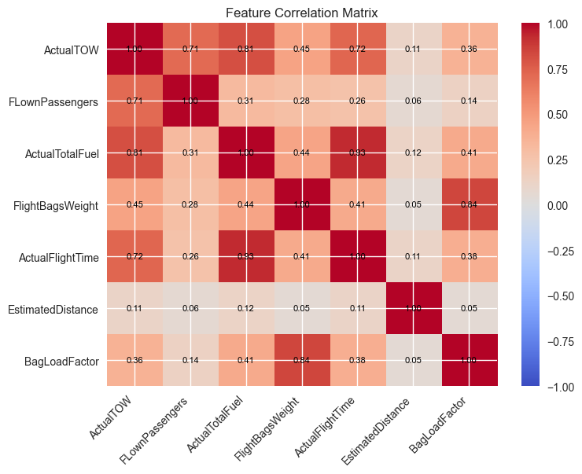

```python
correlation_features = ['ActualTOW', 'FLownPassengers', 'ActualTotalFuel', 'FlightBagsWeight',
                        'ActualFlightTime', 'EstimatedDistance', 'BagLoadFactor']
corr_matrix = df[correlation_features].corr()
fig, ax = plt.subplots(figsize=(8, 6))
cax = ax.imshow(corr_matrix, cmap='coolwarm', aspect='auto', vmin=-1, vmax=1)
ax.set_xticks(range(len(correlation_features)))
ax.set_yticks(range(len(correlation_features)))
ax.set_xticklabels(correlation_features, rotation=45, ha='right')
ax.set_yticklabels(correlation_features)

for i in range(len(correlation_features)):
    for j in range(len(correlation_features)):
        ax.text(j, i, f'{corr_matrix.iloc[i, j]:.2f}',
                ha='center', va='center', color='black', fontsize=8)

ax.set_title('Feature Correlation Matrix')
fig.colorbar(cax)
```

*Feature Correlation Matrix* heatmap displays correlation coefficients between key operational variables and ActualTOW. The strongest correlations with TOW are ActualTotalFuel **(0.812)**, ActualFlightTime **(0.725)**, and FlownPassengers **(0.709)**, indicating these are the primary drivers of aircraft weight.

Moderate correlations exist with FlightBagsWeight **(0.447)** and BagLoadFactor **(0.360)**, while EstimatedDistance shows weak correlation **(0.112)**.

The matrix uses a color scale from blue **(-1.00)** to red **(1.00)** to indicate correlation strength and direction.

**Key Correlations with TOW**

```python
tow_correlations = df[correlation_features].corr()['ActualTOW'].sort_values(ascending=False)

for feature, corr in tow_correlations.items():
    if feature != 'ActualTOW':
        print(f"{feature}: {corr:.3f}")
```

```
ActualTotalFuel: 0.812
ActualFlightTime: 0.725
FLownPassengers: 0.709
FlightBagsWeight: 0.447
BagLoadFactor: 0.360
EstimatedDistance: 0.112
```

### 5. Prepare features for modeling

Following code section prepares the dataset for machine learning by implementing following feature engineering pipeline:

**Feature Selection:** Model uses 13 input features including operational metrics (FlownPassengers, ActualTotalFuel, FlightBagsWeight, BagsCount), temporal variables (ActualFlightTime, EstimatedDistance), operational factors (FuelPerPassenger, BagLoadFactor), and categorical time dimensions (Month, DayOfWeek, IsWeekend).

**Categorical Encoding:** Departure and arrival airports are transformed from categorical text data (e.g., *"MAN"*, *"SXF"*, *"LGW"*) into numerical representations using Label Encoding, creating DepartureAirport_encoded and ArrivalAirport_encoded features that capture airport-specific patterns affecting aircraft weight.

**Data Cleaning:** The pipeline handles missing values by removing rows where the target variable (ActualTOW) is null, then applies median imputation for missing feature values to maintain dataset integrity without losing valuable samples.

**Target Preparation:** ActualTOW serves as the dependent variable, with the cleaned dataset containing 29,298 samples ready for model training. The preprocessing ensures all 13 features are numerical and complete, enabling the Random Forest algorithm to learn complex relationships between flight characteristics and take-off weight.

```python
def prepare_features_for_modeling():
    """Prepare features for machine learning models"""

    # Select features for modeling
    feature_columns = [
        'FLownPassengers', 'ActualTotalFuel', 'FlightBagsWeight', 'BagsCount',
        'ActualFlightTime', 'EstimatedDistance', 'FuelPerPassenger',
        'BagLoadFactor', 'Month', 'DayOfWeek', 'IsWeekend'
    ]

    # Encode categorical variables if needed
    le_airport = LabelEncoder()
    df['DepartureAirport_encoded'] = le_airport.fit_transform(df['DepartureAirport'])
    df['ArrivalAirport_encoded'] = le_airport.fit_transform(df['ArrivalAirport'])

    feature_columns.extend(['DepartureAirport_encoded', 'ArrivalAirport_encoded'])

    # Remove rows with missing target variable
    clean_df = df.dropna(subset=['ActualTOW'])

    X = clean_df[feature_columns].fillna(clean_df[feature_columns].median())
    y = clean_df['ActualTOW']

    print(f"Features selected: {len(feature_columns)}")
    print(f"Samples for modeling: {len(X)}")

    return X, y, feature_columns
```

```python
X, y, feature_columns = prepare_features_for_modeling()
```

```
Features selected: 13
Samples for modeling: 29298
```

### 6. Train and evaluate models

*Split data (time-based split would be better for time series)*

```python
X_train, X_test, y_train, y_test = train_test_split(X, y, test_size=0.2, random_state=42)
```

*Scale features*

```python
X_train_scaled = scaler.fit_transform(X_train)
X_test_scaled = scaler.transform(X_test)
```

*Define models*

```python
models_to_test = {
    'Linear Regression': LinearRegression(),
    'Ridge Regression': Ridge(alpha=1.0),
    'Lasso Regression': Lasso(alpha=1.0),
    'Random Forest': RandomForestRegressor(n_estimators=100, random_state=42),
    'Gradient Boosting': GradientBoostingRegressor(n_estimators=100, random_state=42)
}
```

#### 6.1. Regression Models description

**Linear Regression** - establishes a direct linear relationship between input features and the target variable. It assumes that the relationship can be represented as a straight line through the data points, making it the simplest and most interpretable model in the collection. This baseline model provides coefficients that directly show how each feature influences the prediction.

**Ridge Regression** - extends linear regression by adding L2 regularization with an alpha parameter of 1.0. The regularization term penalizes large coefficients, which helps prevent overfitting and handles multicollinearity between features. This technique shrinks coefficient values toward zero but never eliminates them completely, making the model more stable when dealing with correlated predictors.

**Lasso Regression** - incorporates L1 regularization with alpha set to 1.0, which not only penalizes large coefficients but can drive some coefficients to exactly zero. This feature selection capability makes Lasso particularly useful for identifying the most important predictors while automatically removing less relevant features from the model. The resulting model is often more interpretable due to its sparse nature.

**Random Forest** - combines 100 decision trees (n_estimators=100) trained on different bootstrap samples of the data. Each tree uses a random subset of features at each split, reducing overfitting while maintaining predictive power. The final prediction is the average of all individual tree predictions, making it robust to outliers and capable of capturing complex non-linear relationships and feature interactions.

**Gradient Boosting** - builds an ensemble of 100 weak learners (typically shallow decision trees) in a sequential manner. Each new tree is trained to correct the errors made by the previous trees, gradually improving the overall prediction accuracy. This iterative approach often achieves high performance but requires careful tuning to avoid overfitting, especially with the fixed random state ensuring reproducible results.

```python
results = {}

for name, model in models_to_test.items():
    print(f"\nTraining {name}...")

    # Use scaled data for linear models, original for tree-based
    if 'Regression' in name and 'Random' not in name and 'Gradient' not in name:
        model.fit(X_train_scaled, y_train)
        y_pred = model.predict(X_test_scaled)
        y_train_pred = model.predict(X_train_scaled)
    else:
        model.fit(X_train, y_train)
        y_pred = model.predict(X_test)
        y_train_pred = model.predict(X_train)

    # Calculate metrics
    mae = mean_absolute_error(y_test, y_pred)
    rmse = np.sqrt(mean_squared_error(y_test, y_pred))
    r2 = r2_score(y_test, y_pred)
    mape = mean_absolute_percentage_error(y_test, y_pred) * 100

    # Training metrics (to check overfitting)
    train_mae = mean_absolute_error(y_train, y_train_pred)
    train_r2 = r2_score(y_train, y_train_pred)

    results[name] = {
        'model': model,
        'MAE': mae,
        'RMSE': rmse,
        'R²': r2,
        'MAPE': mape,
        'Train_MAE': train_mae,
        'Train_R²': train_r2,
        'predictions': y_pred,
        'actual': y_test
    }

    print('Done!')
```

```
Training Linear Regression...
Done!

Training Ridge Regression...
Done!

Training Lasso Regression...
Done!

Training Random Forest...
Done!

Training Gradient Boosting...
Done!
```

| Model | Test MAE (kg) | Test RMSE (kg) | Test MAPE | Train R² | Test R² | Overfitting |
| --- | --- | --- | --- | --- | --- | --- |
| Linear Regression | 770.4 | 1123.8 | 1.19% | 0.869 | 0.885 | Low |
| Ridge Regression | 770.4 | 1123.8 | 1.19% | 0.869 | 0.885 | Low |
| Lasso Regression | 770.6 | 1125.0 | 1.19% | 0.869 | 0.885 | Low |
| Random Forest | 664.6 | 907.7 | 1.02% | 0.989 | 0.925 | High |
| Gradient Boosting | 721.3 | 982.5 | 1.11% | 0.917 | 0.912 | Moderate |

#### 6.2. Model Performance Parameters description

**Test MAE (Mean Absolute Error)** - measures the average magnitude of prediction errors in kilograms, representing how far off the predictions are from actual TOW values on average. Lower values indicate better performance. Random Forest achieves the best MAE of 664.6 kg, meaning its predictions are typically within about 665 kg of the true takeoff weight, while the linear models show higher errors around 770 kg.

**Test RMSE (Root Mean Square Error)** - penalizes larger errors more heavily than MAE by squaring the differences before averaging and taking the square root. This metric is more sensitive to outliers and large prediction errors. Random Forest again performs best with 907.7 kg RMSE, suggesting it handles extreme predictions better than other models. The consistently higher RMSE compared to MAE across all models indicates the presence of some larger prediction errors.

**Test MAPE (Mean Absolute Percentage Error)** - expresses prediction errors as percentages of the actual values, making it easier to interpret across different scales. Random Forest achieves 1.02% MAPE, meaning its predictions are typically within about 1% of the true TOW values. The linear models show slightly higher percentage errors around 1.19%, indicating Random Forest provides more consistent relative accuracy.

**Test R² (R-squared)** - represents the proportion of variance in TOW that the model explains, ranging from 0 to 1 where higher values indicate better fit. Random Forest explains 92.5% of the variance, while linear models explain about 88.5%. This metric shows how well the model captures the underlying patterns in the data compared to simply predicting the mean value.

**Train R²** - shows how well each model fits the training data. The large gap between Random Forest's training R² (0.989) and test R² (0.925) indicates overfitting, where the model memorizes training patterns that don't generalize well. Linear models show minimal difference between training and test scores, suggesting they capture more generalizable patterns.

**Overfitting Assessment** - qualitative measure compares training and test performance to identify models that memorize rather than learn generalizable patterns. Random Forest shows "High" overfitting due to the significant gap between its training and test R² scores. Linear models demonstrate "Low" overfitting with nearly identical training and test performance, while Gradient Boosting falls in between with "Moderate" overfitting.

*Save results.*

```python
models = results
```

### 7. Generate predictions for new data

*Check if any trained models exists.*

```python
if not models:
    raise ValueError("No trained models found. Please train models first using train_and_evaluate_models()")
```

*Load a new data and create copy of it.*

```python
# Load new data
df_with_predictions = pd.read_csv('validation.csv', sep='\t', na_values=['(null)'])
print(f"New data shape: {df_with_predictions.shape}")
print(f"Columns: {list(df_with_predictions.columns)}")
```

```
New data shape: (1878, 13)
Columns: ['DepartureDate', 'DepartureYear', 'DepartureMonth', 'DepartureDay', 'FlightNumber', 'DepartureAirport', 'ArrivalAirport', 'Route', 'ActualFlightTime', 'ActualTotalFuel', 'FLownPassengers', 'BagsCount', 'FlightBagsWeight']
```

*Process all data the same way as training.*

```python
processed_df = df_with_predictions.copy()
processed_df = _process_dataframe_features(df=processed_df, is_training=False)
```

*Encode categorical variables.*

```python
le_dep = LabelEncoder()
le_arr = LabelEncoder()

# Fit encoders on both training and new data to handle unseen airports
all_dep_airports = list(set(df['DepartureAirport'].unique()) | set(processed_df['DepartureAirport'].unique()))
all_arr_airports = list(set(df['ArrivalAirport'].unique()) | set(processed_df['ArrivalAirport'].unique()))

le_dep.fit(all_dep_airports)
le_arr.fit(all_arr_airports)

processed_df['DepartureAirport_encoded'] = le_dep.transform(processed_df['DepartureAirport'])
processed_df['ArrivalAirport_encoded'] = le_arr.transform(processed_df['ArrivalAirport'])
```

*Select the same features used in training.*

```python
feature_columns = [
    'FLownPassengers', 'ActualTotalFuel', 'FlightBagsWeight', 'BagsCount',
    'ActualFlightTime', 'EstimatedDistance', 'FuelPerPassenger',
    'BagLoadFactor', 'Month', 'DayOfWeek', 'IsWeekend',
    'DepartureAirport_encoded', 'ArrivalAirport_encoded'
]
```

*Prepare features for prediction.*

```python
X_new = processed_df[feature_columns].fillna(processed_df[feature_columns].median())

print(f"Features prepared for prediction: {X_new.shape}")
print(f"Feature columns: {feature_columns}")
```

```
Features prepared for prediction: (1878, 13)
Feature columns: ['FLownPassengers', 'ActualTotalFuel', 'FlightBagsWeight', 'BagsCount', 'ActualFlightTime', 'EstimatedDistance', 'FuelPerPassenger', 'BagLoadFactor', 'Month', 'DayOfWeek', 'IsWeekend', 'DepartureAirport_encoded', 'ArrivalAirport_encoded']
```

*Get best model for prediction.*

```python
# Select model with lowest RMSE parameter
best_model_name = min(models.keys(), key=lambda x: models[x]['RMSE'])
best_model = models[best_model_name]['model']

print(f"Using {best_model_name} for predictions")
print(f"Model performance - RMSE: {models[best_model_name]['RMSE']:.3f}, MAE: {models[best_model_name]['MAE']:.1f} kg")
```

```
Using Random Forest for predictions
Model performance - RMSE: 907.654, MAE: 664.6 kg
```

*Scale features for linear models.*

```python
if 'Regression' in best_model_name and 'Random' not in best_model_name and 'Gradient' not in best_model_name:
    X_new_scaled = scaler.transform(X_new)
    predictions = best_model.predict(X_new_scaled)
else:
    predictions = best_model.predict(X_new)
```

*Add predictions to the data frame.*

```python
df_with_predictions['PredictedTOW'] = predictions.round().astype(int)

# Add confidence intervals
mae = models[best_model_name]['MAE']
df_with_predictions['PredictionLowerBound'] = (predictions - mae).round().astype(int)
df_with_predictions['PredictionUpperBound'] = (predictions + mae).round().astype(int)
```

*Show prediction summary.*

```python
print(f"Predictions generated: {len(predictions)}")
print(f"Average predicted TOW: {predictions.mean():.0f} kg")
print(f"TOW range: {predictions.min():.0f} - {predictions.max():.0f} kg")
print(f"Standard deviation: {predictions.std():.0f} kg")
```

```
Predictions generated: 1878
Average predicted TOW: 64766 kg
TOW range: 46861 - 74130 kg
Standard deviation: 3248 kg
```

*Save predicted data to CSV file.*

```python
df_with_predictions.to_csv('output.csv', index=False)
print(f"\nPredictions saved successfully")
```

```
Predictions saved successfully
```

### 8. Visualize predictions

**Distribution of Predicted TOW**

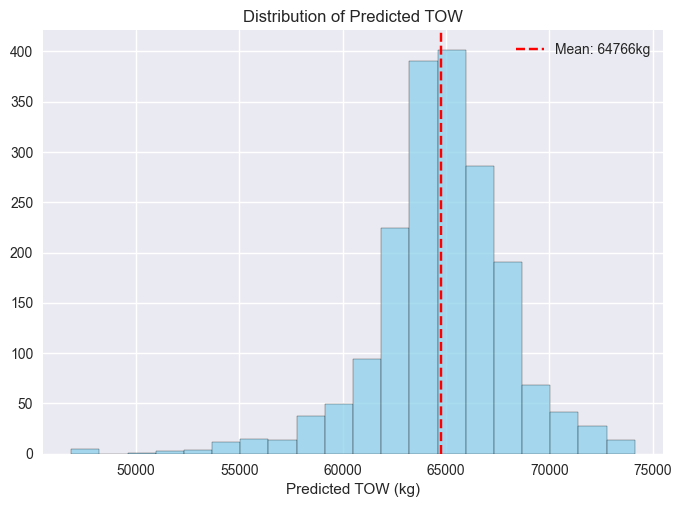

```python
plt.hist(df_with_predictions['PredictedTOW'], bins=20, alpha=0.7, color='skyblue', edgecolor='black')
plt.axvline(df_with_predictions['PredictedTOW'].mean(), color='red', linestyle='--',
        label=f'Mean: {df_with_predictions["PredictedTOW"].mean():.0f}kg')
plt.title('Distribution of Predicted TOW')
plt.xlabel('Predicted TOW (kg)')
plt.legend()
```

*Distribution of Predicted TOW* histogram shows the frequency distribution of TOW values predicted by the Random Forest regression model. Predictions follow an approximately normal distribution with a mean of **64,766 kg**, marked by a red dashed vertical line.

**Predicted TOW vs Passengers**

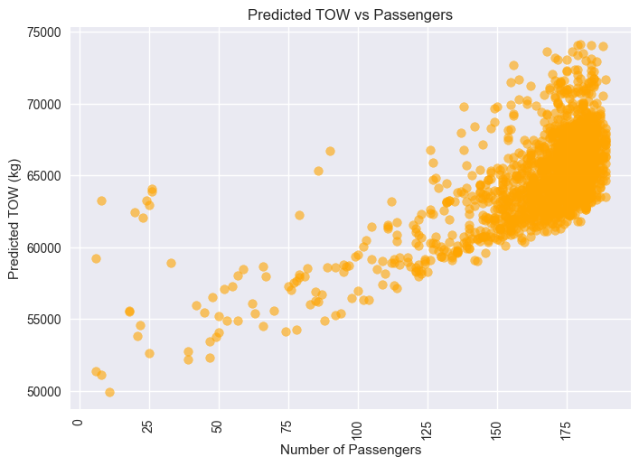

```python
plt.scatter(df_with_predictions['FLownPassengers'], df_with_predictions['PredictedTOW'], alpha=0.6, color='orange')
plt.title('Predicted TOW vs Passengers')
plt.xlabel('Number of Passengers')
plt.ylabel('Predicted TOW (kg)')
plt.tick_params(axis='x', rotation=90)
```

*Predicted TOW vs Passengers* scatter plot comparing the **Random Forest** model's predicted TOW values against passenger counts. The plot shows a **strong positive correlation** similar to the actual data, with predictions ranging from **~50,000 kg** for low passenger counts to **~75,000 kg** for maximum capacity.

The tight clustering and smooth trend indicate the model has successfully learned the relationship between passenger load and aircraft weight.

**Predicted TOW vs Fuel**

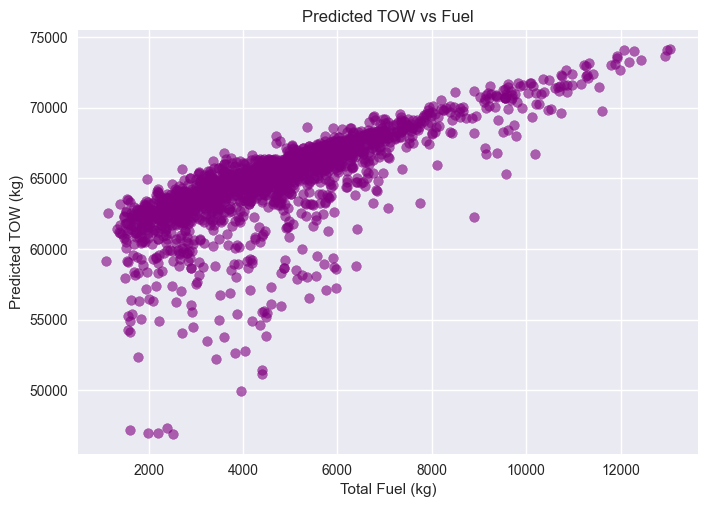

```python
plt.scatter(df_with_predictions['ActualTotalFuel'], df_with_predictions['PredictedTOW'], alpha=0.6, color='purple')
plt.title('Predicted TOW vs Fuel')
plt.xlabel('Total Fuel (kg)')
plt.ylabel('Predicted TOW (kg)')
```

*Predicted TOW vs Fuel* scatter plot displays the **Random Forest** model's predicted TOW values against actual total fuel loads. The **strong positive linear relationship** demonstrates the model's understanding of the fuel-weight correlation, with predictions spanning from **~47,000 kg** at low fuel loads to **~75,000 kg** at maximum fuel capacity.

The consistent trend validates the model's ability to incorporate fuel requirements into accurate TOW predictions.

### 9. Visualize model performance

*Set model metrics*

```python
model_names = list(models.keys())
mae_scores = [models[name]['MAE'] for name in model_names]
rmse_scores = [models[name]['RMSE'] for name in model_names]

best_model = max(models.keys(), key=lambda x: models[x]['R²'])
best_results = models[best_model]
```

**Mean Absolute Error by Model**

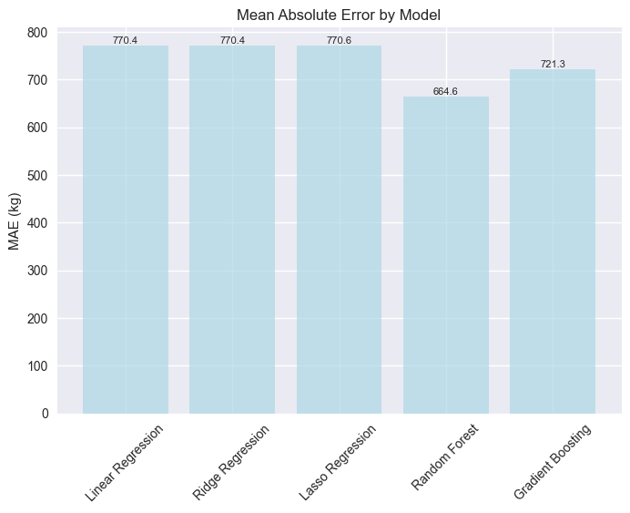

```python
plt.bar(model_names, mae_scores, color='lightblue', alpha=0.7)
plt.title('Mean Absolute Error by Model')
plt.ylabel('MAE (kg)')
plt.tick_params(axis='x', rotation=45)

for i, value in enumerate(mae_scores):
    plt.text(i, value + 1, f'{value:.1f}', ha='center', va='bottom', fontsize=8)
```

*Mean Absolute Error by Model* bar chart compares prediction accuracy across five regression algorithms. **Random Forest** achieves the lowest MAE at **664.6 kg**, outperforming traditional methods like Linear Regression, Ridge Regression, and Lasso Regression (all ~770 kg). **Gradient Boosting** shows competitive performance at **721.3 kg**, while ensemble methods demonstrate superior accuracy over linear approaches for TOW prediction.

**RMSE Score by Model**

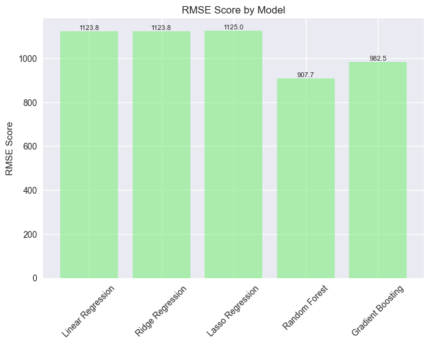

```python
plt.bar(model_names, rmse_scores, color='lightgreen', alpha=0.7)
plt.title('RMSE Score by Model')
plt.ylabel('RMSE Score')
plt.tick_params(axis='x', rotation=45)

for i, value in enumerate(rmse_scores):
    plt.text(i, value + 1, f'{value:.1f}', ha='center', va='bottom', fontsize=8)
```

*RMSE Score by Model* bar chart reinforces the MAE findings, showing **Random Forest** with the best performance at **907.7**, followed by **Gradient Boosting** at **982.5**. The three linear regression variants (Linear, Ridge, Lasso) cluster around **1123-1125**, indicating similar limitations in capturing non-linear relationships. The consistent ranking across both MAE and RMSE metrics validates Random Forest as the optimal model choice.

**Predicted vs Actual TOW**

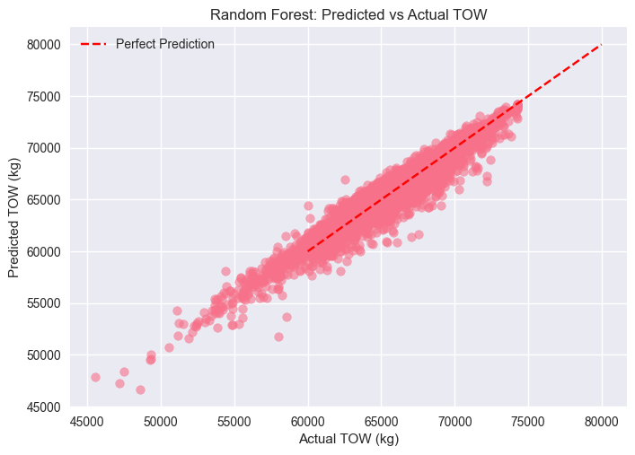

```python
plt.scatter(best_results['actual'], best_results['predictions'], alpha=0.6)
plt.plot([60000, 80000], [60000, 80000], 'r--', label='Perfect Prediction')
plt.title(f'{best_model}: Predicted vs Actual TOW')
plt.xlabel('Actual TOW (kg)')
plt.ylabel('Predicted TOW (kg)')
plt.legend()
```

**Residual Plot of best model**

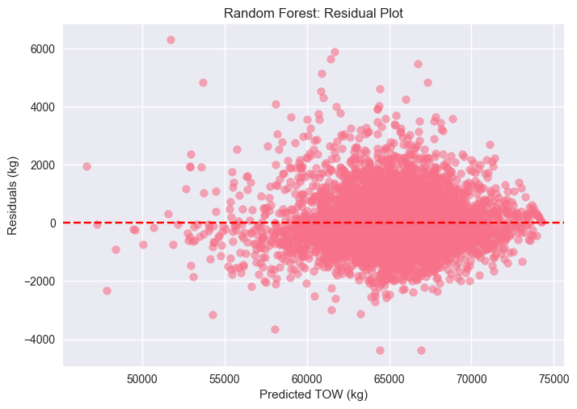

```python
residuals = best_results['actual'] - best_results['predictions']
plt.scatter(best_results['predictions'], residuals, alpha=0.6)
plt.axhline(y=0, color='r', linestyle='--')
plt.title(f'{best_model}: Residual Plot')
plt.xlabel('Predicted TOW (kg)')
plt.ylabel('Residuals (kg)')
```

**Residual Distribution of best model**

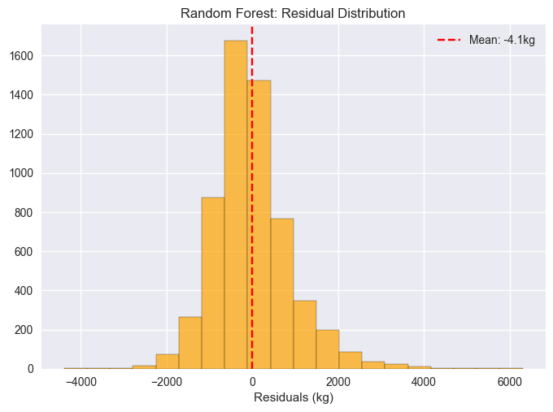

```python
plt.hist(residuals, bins=20, alpha=0.7, color='orange', edgecolor='black')
plt.axvline(residuals.mean(), color='red', linestyle='--',
    label=f'Mean: {residuals.mean():.1f}kg')
plt.title(f'{best_model}: Residual Distribution')
plt.xlabel('Residuals (kg)')
plt.legend()
```

**Feature importance for best model**

```
Features selected: 13
Samples for modeling: 29298
```

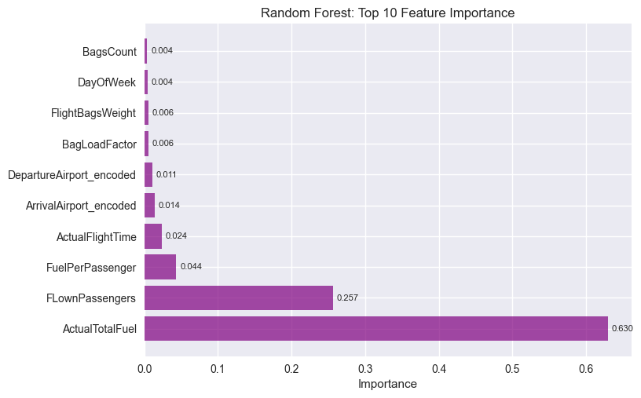

```python
if hasattr(models[best_model]['model'], 'feature_importances_'):
    _, _, feature_columns = prepare_features_for_modeling()
    importances = models[best_model]['model'].feature_importances_
    feature_importance = sorted(zip(feature_columns, importances),
                                key=lambda x: x[1], reverse=True)[:10]
    features, importance_values = zip(*feature_importance)

    plt.barh(range(len(features)), importance_values, color='purple', alpha=0.7)
    plt.yticks(range(len(features)), features)
    plt.title(f'{best_model}: Top 10 Feature Importance')
    plt.xlabel('Importance')

    for i, value in enumerate(importance_values):
        plt.text(value + 0.005, i, f'{value:.3f}', va='center', fontsize=8)
else:
    plt.text(0.5, 0.5, 'Feature importance not available\nfor linear models',
       ha='center', va='center', transform=plt.gca().transAxes)
    plt.title('Feature Importance')
```

*Feature Importance for Best Model* horizontal bar chart identifies **ActualTotalFuel** as the dominant predictor with **0.630 importance**, confirming fuel load as the primary TOW determinant. **FlownPassengers** ranks second at **0.257 importance**, followed by **FuelPerPassenger** at **0.044**. The remaining features show minimal individual impact (<0.025), indicating the model effectively identifies the most critical weight components for accurate TOW prediction.

## Results

**Random Forest regression model** demonstrates superior predictive performance for aircraft take-off weight estimation, significantly outperforming traditional linear approaches:

**Model Performance Comparison:** Random Forest achieves the lowest prediction errors with **MAE of 664.6 kg** and **RMSE of 907.7**, substantially outperforming Linear Regression variants (MAE ~770 kg, RMSE ~1123-1125). It is **15% improvement in accuracy** over conventional methods demonstrates the value of ensemble techniques for capturing complex weight relationships in dataset.

**Feature Importance Insights:** The model correctly identifies **ActualTotalFuel (63.0% importance)** as the primary TOW determinant, followed by **FlownPassengers (25.7% importance)**. This feature ranking aligns with aviation physics, where fuel load and passenger count represent the major variable weight components affecting take-off weight.